# Overview of Statistical vs machine learning models

March 28, 2018

## Types of model with data

- Deterministic models
  - purpose is to explain physical phenomenon
  - Example: differential equations, operational research (OR)
- Predictive models
  - purpose is to predict only
  - actual model is a black box and is not in focus
  - model is considered good as long as it can predict well
  - Example: machine learning and data mining
- Statistical models
  - purpose is to predict and explain the physical phenomenon
  - model should be suitable for the data generating mechanism
  - model is good if it can both predict and explain the physical relationship
  - examples: Linear model, time series

## Statistical and Machine learning models

- Statistical models
  - simple Linear model,
  - generalized linear model (GLM)
  - mixed effect model
  - time series
  - ANOVA
- Machine learning models
  - Decision Tree
  - Artificial Neural Network
  - Support Vector Machine (SVM)

## Basics of statistical model

- Assumption about population
- Sampling from the population
- Obtain the parameters of the model based on the sample
  - Maximum Likelihood, Moment estimates
- Use the model to explain the population characteristics
  - predict or forecast
  - explain why and how

## Simple linear regression

- A simple linear regression model has the following form \[Y = \beta_0 + \beta_1 X + \sigma \epsilon\]
- The notations
  - \(Y\) is called response variable
  - \(X\) is called predictor or covariate that explains the variability in \(Y\)
    - \(X\) could be continuous or categorical (ANOVA model)
  - \(\beta_0\) is intercept and \(\beta_1\) is the slope, \(\sigma\) is standard deviation .
  - \(\epsilon\) is called the error term
    - it is assumed that \(\epsilon \stackrel{id}{\sim} N(0,1)\)

## Assumptions of linear model

- Important assumptions in a linear model
  - \(Y|X\) is always continuous
  - \(\beta_0\), \(\beta_1\) are all fixed
  - Linearity
  - Independence
  - Equal variance (\(\sigma\) is fixed)
  - Normality
- Never fit a linear regression model if first five assumptions are not satisfied
  - Normality assumption is needed for inference, but for large data it is OK any way

## What if assumptions are not satisfied

- \(Y|X\) is always continuous
  - Generalized Linear Model
  - Machine learning model
- \(\beta_0\), \(\beta_1\) are all fixed
  - consider hierarchical model / Bayesian model, mixed effect model
- Linearity
  - transforming covariates may solve non-linearity issue
  - consider machine learning models
- Independence
  - aggregate data to experimental unit
  - time series or stochastic or machine learning models

## What if assumptions are not satisfied

- Equal variance (\(Var(Y|X)= \sigma^2\) is fixed and same for all \(X\))
  - transform data to stabilize variance (Box-cox transformation)
  - consider hierarchical model, Bayesian model
- Normality
  - (1)often transformation normalize the data, (2) work with aggregated data so that Central Limit Theorem (CLT) applies, (3) gather more data
  - Consider Generalized Linear Model (GLM)

## Machine learning vs statistical models

- In review of statistical models, machine learning models show up when
  - \(Y|X\) is not continuous
  - Linearity assumption can't be satisfied
  - Independence assumption can't be satisfied
- Is there other situations where machine learning is preferable
  - Big data: statistical models often over fit
  - \(n \rightarrow \infty\) every signal (no matter how small) is statistically significant
  - When we only need predictability (Who cares about physical mechanism?)
- What do we loose when prefer machine learning over statistical models?
  - data generation mechanism
  - machine learning models are not designed to explain physical phenomenon

## Case Study: Linearity

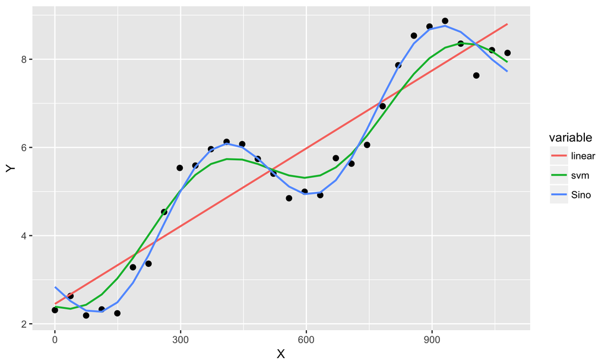

## Case Study: Linearity

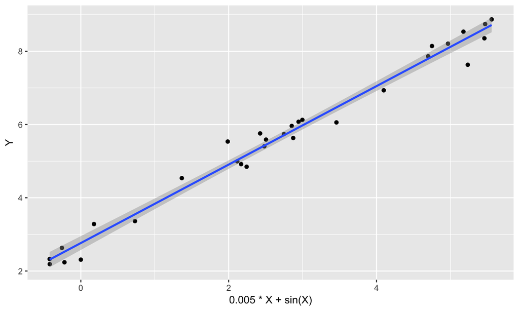

```r
qplot(0.005*X + sin(X), Y) + geom_smooth(method="lm")
```

## Conclusion

- We prefer statistical model
  - provides more than just predictability
  - data generation mechanism
  - mixer models
  - transformation of data may help
- Machine learning models are useful
  - massive data
  - predictability
  - ensemble modeling